# Twitter Feeds

Import packages

```python
from tweepy import Stream
from tweepy import OAuthHandler
from tweepy.streaming import StreamListener
import pandas as pd
import json
from textblob import TextBlob
```

```python
#https://github.com/shreyans29/thesemicolon/blob/master/livesenti.py

df_tweets = pd.DataFrame(columns = ['count', 'tweet', 'senti'])
count=0

class listener(StreamListener):

    def on_data(self,data):
        all_data=json.loads(data)
        tweet=all_data["text"]
        #username=all_data["user"]["screen_name"]
        blob=TextBlob(tweet.strip())

        global count
        global df_tweets

        count=count+1

        if count%50 == 0:
            print(count)
        df_tweets = df_tweets.append(pd.DataFrame({'count':[count], 'tweet':[tweet.strip()]}))

        if count==6000:
            df_tweets.to_csv('df_tweet.csv')
            return(False)
        else:
            return(True)

    def on_error(self,status):
        print(status)

atoken = "1009156045988491264-nzRbKNnbbHOgE9Qx8MgYrGqUEIZzqO"
asecret = "yPsJFcSoeh1M20RnIkz9dC5VVfbSgiWkUI4EVFkj6nKc2"
ckey = "BaOWdsvJJwXvlHO1FNyfAIqk5"
csecret = "nmiAfhPun8pkh76DUY96FYeYxSWoxblt7V9AnMiKxZU8FwWMXE"

auth=OAuthHandler(ckey,csecret)
auth.set_access_token(atoken,asecret)

twitterStream=  Stream(auth, listener(count))
twitterStream.filter(track=["uber"], languages=['en'])
```

[output not shown]

[output cut: 65 more lines]

```
5300
5350
5400
5450
5500
5550
5600
5650
5700
5750
5800
5850
5900
5950
6000
```

```python
df_tweets = pd.read_csv('df_tweet.csv')
```

Take out the characters that the computer can't understand from the code.

```python
df_tweets.tweet = df_tweets.tweet.map(lambda x: x.encode('ascii',errors='ignore'))
```

Turn all the tweets into lower case.

```python
df_tweets.tweet = df_tweets.tweet.map(lambda x: x.lower())
```

Look at the first five tweets to see that they have been correctly modified.

```python
df_tweets.tweet.head()
```

```
0     b'this line up is trash...... take me back 2014'
1    b'rt @blackboyymagic: sitting in the back text...
2    b'rt @nickjohonas: summer 16 had:\r\n"one danc...
3    b'rt @blackboyymagic: sitting in the back text...
4    b'rt @blackboyymagic: sitting in the back text...
Name: tweet, dtype: object
```

Find the sentiments of each tweet and turn that into a column of our dataframe.

```python
df_tweets['senti'] = df_tweets.tweet.map(lambda x: TextBlob(str(x)).sentiment.polarity)
```

```python
df_tweets.head()
```

|  | Unnamed: 0 | count | senti | tweet |
| --- | --- | --- | --- | --- |
| 0 | 0 | 1 | 0.0 | b'this line up is trash...... take me back 2014' |
| 1 | 0 | 2 | 0.3 | b'rt @blackboyymagic: sitting in the back text... |
| 2 | 0 | 3 | 0.0 | b'rt @nickjohonas: summer 16 had:\r\n"one danc... |
| 3 | 0 | 4 | 0.3 | b'rt @blackboyymagic: sitting in the back text... |
| 4 | 0 | 5 | 0.3 | b'rt @blackboyymagic: sitting in the back text... |

Find the overall sentiment score.

```python
df_tweets.senti.sum()
```

```
1067.345152419918
```

Now, we will make two dataframes, one for the positive tweets and one for the negative tweets.

```python
from wordcloud import WordCloud
import matplotlib.pyplot as plt
pos_tweets = df_tweets.tweet[df_tweets.senti>0]
neg_tweets = df_tweets.tweet[df_tweets.senti<0]
```

Print the average positive sentiment score and the average negative sentiment score.

```python
print(df_tweets.senti[df_tweets.senti>0].sum()/df_tweets.senti[df_tweets.senti>0].shape[0])
print(df_tweets.senti[df_tweets.senti<0].sum()/df_tweets.senti[df_tweets.senti<0].shape[0])
```

```
0.3173476337385158
-0.2972236284758037
```

Display the first five positive tweets.

Note: I decided to keep the retweets since they indicate the popularity of a tweet.

```python
pos_tweets.head()
```

```
1    b'rt @blackboyymagic: sitting in the back text...
3    b'rt @blackboyymagic: sitting in the back text...
4    b'rt @blackboyymagic: sitting in the back text...
5    b'rt @blackboyymagic: sitting in the back text...
7    b'rt @blackboyymagic: sitting in the back text...
Name: tweet, dtype: object
```

Display the first five negative tweets.

```python
neg_tweets.head()
```

```
6     b'rt @hamilton6connor: had a conversation with...
12    b'rt @larryelder: "black conservatives kicked ...
16    b'rt @hamilton6connor: had a conversation with...
30    b'rt @trumpera_2017: woman calls the cops on b...
34    b'rt @gagasyuyi: summer 09 had:\r\n\r\nbad rom...
Name: tweet, dtype: object
```

Create a wordcloud for the positive tweets.

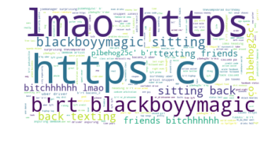

```python
wordcloud = WordCloud(background_color = 'white').generate(' '.join(pos_tweets.astype(str)))
plt.imshow(wordcloud, interpolation='bilinear')
plt.axis("off")
plt.show()
```

Create a wordcloud for the negative tweets.

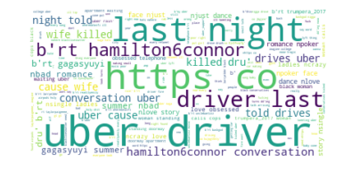

```python
wordcloud2 = WordCloud(background_color = 'white').generate(' '.join(neg_tweets.astype(str)))
plt.imshow(wordcloud2, interpolation='bilinear')
plt.axis("off")
plt.show()
```